# Dataset Explained:

Background: Starbucks and McDonalds are two of the largest fast food chains in the United States and on the planet. Both companies offer breakfast items such as coffee, sandwiches, etc.

The Overall Task: My goal is to evaluate both companies similar items (in this case I will be looking at the drinks) and provide analysis on them as I see fit. There are a couple of things that I would like to find out:

```
1. On average, which company has the better nutrition values? - my personal theory is that McDonalds does        becasue most of Starbucks drinks have things like whipped cream, all different types of flavorings, etc. which probably make them less healthy
2. If they sell any of the same drink, which is better for you?
3. Is there a good way to display the nutrition facts for each item?
4. How similar are each item in each datasets based on their nutritional values?
```

The Datasets: I will be working with two datasets in this project. One of them is the Starbucks drink menu and the other is the entire McDonalds menu. Below are the two datasets shown as pandas dataframes.

[figure not shown]

```python
import pandas as pd
import numpy as np
import regex as re
import matplotlib.pyplot as plt
import plotly.express as px
from sklearn.cluster import KMeans
from sklearn.preprocessing import StandardScaler
from sklearn.decomposition import PCA
```

```python
starbucks_df = pd.read_csv('starbucks-menu-nutrition-drinks.csv')
mcdonalds_df = pd.read_csv('menu.csv')
```

```python
print('Starbucks:')
display(starbucks_df)
print()
print('McDonalds:')
display(mcdonalds_df)
```

```
Starbucks:
```

|  | Unnamed: 0 | Calories | Fat (g) | Carb. (g) | Fiber (g) | Protein | Sodium |
| --- | --- | --- | --- | --- | --- | --- | --- |
| 0 | Cool Lime Starbucks Refreshers™ Beverage | 45 | 0 | 11 | 0 | 0 | 10 |
| 1 | Ombré Pink Drink | - | - | - | - | - | - |
| 2 | Pink Drink | - | - | - | - | - | - |
| 3 | Strawberry Acai Starbucks Refreshers™ Beverage | 80 | 0 | 18 | 1 | 0 | 10 |
| 4 | Very Berry Hibiscus Starbucks Refreshers™ Beve... | 60 | 0 | 14 | 1 | 0 | 10 |
| ... | ... | ... | ... | ... | ... | ... | ... |
| 172 | Chocolate Smoothie | 320 | 5 | 53 | 8 | 20 | 170 |
| 173 | Strawberry Smoothie | 300 | 2 | 60 | 7 | 16 | 130 |
| 174 | Ginger Ale | - | - | - | - | - | - |
| 175 | Lemon Ale | - | - | - | - | - | - |
| 176 | Orange Cream Soda | - | - | - | - | - | - |

177 rows × 7 columns

```
McDonalds:
```

|  | Category | Item | Serving Size | Calories | Calories from Fat | Total Fat | Total Fat (% Daily Value) | Saturated Fat | Saturated Fat (% Daily Value) | Trans Fat | ... | Carbohydrates | Carbohydrates (% Daily Value) | Dietary Fiber | Dietary Fiber (% Daily Value) | Sugars | Protein | Vitamin A (% Daily Value) | Vitamin C (% Daily Value) | Calcium (% Daily Value) | Iron (% Daily Value) |
| --- | --- | --- | --- | --- | --- | --- | --- | --- | --- | --- | --- | --- | --- | --- | --- | --- | --- | --- | --- | --- | --- |
| 0 | Breakfast | Egg McMuffin | 4.8 oz (136 g) | 300 | 120 | 13.0 | 20 | 5.0 | 25 | 0.0 | ... | 31 | 10 | 4 | 17 | 3 | 17 | 10 | 0 | 25 | 15 |
| 1 | Breakfast | Egg White Delight | 4.8 oz (135 g) | 250 | 70 | 8.0 | 12 | 3.0 | 15 | 0.0 | ... | 30 | 10 | 4 | 17 | 3 | 18 | 6 | 0 | 25 | 8 |
| 2 | Breakfast | Sausage McMuffin | 3.9 oz (111 g) | 370 | 200 | 23.0 | 35 | 8.0 | 42 | 0.0 | ... | 29 | 10 | 4 | 17 | 2 | 14 | 8 | 0 | 25 | 10 |
| 3 | Breakfast | Sausage McMuffin with Egg | 5.7 oz (161 g) | 450 | 250 | 28.0 | 43 | 10.0 | 52 | 0.0 | ... | 30 | 10 | 4 | 17 | 2 | 21 | 15 | 0 | 30 | 15 |
| 4 | Breakfast | Sausage McMuffin with Egg Whites | 5.7 oz (161 g) | 400 | 210 | 23.0 | 35 | 8.0 | 42 | 0.0 | ... | 30 | 10 | 4 | 17 | 2 | 21 | 6 | 0 | 25 | 10 |
| ... | ... | ... | ... | ... | ... | ... | ... | ... | ... | ... | ... | ... | ... | ... | ... | ... | ... | ... | ... | ... | ... |
| 255 | Smoothies & Shakes | McFlurry with Oreo Cookies (Small) | 10.1 oz (285 g) | 510 | 150 | 17.0 | 26 | 9.0 | 44 | 0.5 | ... | 80 | 27 | 1 | 4 | 64 | 12 | 15 | 0 | 40 | 8 |
| 256 | Smoothies & Shakes | McFlurry with Oreo Cookies (Medium) | 13.4 oz (381 g) | 690 | 200 | 23.0 | 35 | 12.0 | 58 | 1.0 | ... | 106 | 35 | 1 | 5 | 85 | 15 | 20 | 0 | 50 | 10 |
| 257 | Smoothies & Shakes | McFlurry with Oreo Cookies (Snack) | 6.7 oz (190 g) | 340 | 100 | 11.0 | 17 | 6.0 | 29 | 0.0 | ... | 53 | 18 | 1 | 2 | 43 | 8 | 10 | 0 | 25 | 6 |
| 258 | Smoothies & Shakes | McFlurry with Reese's Peanut Butter Cups (Medium) | 14.2 oz (403 g) | 810 | 290 | 32.0 | 50 | 15.0 | 76 | 1.0 | ... | 114 | 38 | 2 | 9 | 103 | 21 | 20 | 0 | 60 | 6 |
| 259 | Smoothies & Shakes | McFlurry with Reese's Peanut Butter Cups (Snack) | 7.1 oz (202 g) | 410 | 150 | 16.0 | 25 | 8.0 | 38 | 0.0 | ... | 57 | 19 | 1 | 5 | 51 | 10 | 10 | 0 | 30 | 4 |

260 rows × 24 columns

# Cleaning The Data:

I first want to clean the Starbucks dataset up. These drink values are based on the 12 fl oz sizes. There are multiple items on the menu that do not contain any inforamtion. No information is denoted as '-' on the table. I want to only keep items that have values in the table. I aslo want to rename the item column from 'Unnamed:0' to something that makes more sense.

```python
starbucks_new_df = starbucks_df.rename(columns = {'Unnamed: 0' : 'Item'})
starbucks_new_df = starbucks_new_df.replace('-', np.nan)
starbucks_new_df = starbucks_new_df.dropna().reset_index(drop=True)
starbucks_new_df.iloc[:, 1:] = starbucks_new_df.iloc[:, 1:].astype(float)
```

```python
print("Old DF:")
display(starbucks_df)
print()
print("New DF:")
display(starbucks_new_df)
```

```
Old DF:
```

|  | Unnamed: 0 | Calories | Fat (g) | Carb. (g) | Fiber (g) | Protein | Sodium |
| --- | --- | --- | --- | --- | --- | --- | --- |
| 0 | Cool Lime Starbucks Refreshers™ Beverage | 45 | 0 | 11 | 0 | 0 | 10 |
| 1 | Ombré Pink Drink | - | - | - | - | - | - |
| 2 | Pink Drink | - | - | - | - | - | - |
| 3 | Strawberry Acai Starbucks Refreshers™ Beverage | 80 | 0 | 18 | 1 | 0 | 10 |
| 4 | Very Berry Hibiscus Starbucks Refreshers™ Beve... | 60 | 0 | 14 | 1 | 0 | 10 |
| ... | ... | ... | ... | ... | ... | ... | ... |
| 172 | Chocolate Smoothie | 320 | 5 | 53 | 8 | 20 | 170 |
| 173 | Strawberry Smoothie | 300 | 2 | 60 | 7 | 16 | 130 |
| 174 | Ginger Ale | - | - | - | - | - | - |
| 175 | Lemon Ale | - | - | - | - | - | - |
| 176 | Orange Cream Soda | - | - | - | - | - | - |

177 rows × 7 columns

```
New DF:
```

|  | Item | Calories | Fat (g) | Carb. (g) | Fiber (g) | Protein | Sodium |
| --- | --- | --- | --- | --- | --- | --- | --- |
| 0 | Cool Lime Starbucks Refreshers™ Beverage | 45.0 | 0.0 | 11.0 | 0.0 | 0.0 | 10.0 |
| 1 | Strawberry Acai Starbucks Refreshers™ Beverage | 80.0 | 0.0 | 18.0 | 1.0 | 0.0 | 10.0 |
| 2 | Very Berry Hibiscus Starbucks Refreshers™ Beve... | 60.0 | 0.0 | 14.0 | 1.0 | 0.0 | 10.0 |
| 3 | Evolution Fresh™ Organic Ginger Limeade | 110.0 | 0.0 | 28.0 | 0.0 | 0.0 | 5.0 |
| 4 | Iced Coffee | 0.0 | 0.0 | 0.0 | 0.0 | 0.0 | 0.0 |
| ... | ... | ... | ... | ... | ... | ... | ... |
| 87 | Mocha Light Frappuccino® Blended Coffee | 140.0 | 0.5 | 28.0 | 1.0 | 4.0 | 180.0 |
| 88 | Cinnamon Dolce Crème | 200.0 | 6.0 | 28.0 | 0.0 | 10.0 | 135.0 |
| 89 | Vanilla Crème | 200.0 | 6.0 | 28.0 | 0.0 | 10.0 | 135.0 |
| 90 | Chocolate Smoothie | 320.0 | 5.0 | 53.0 | 8.0 | 20.0 | 170.0 |
| 91 | Strawberry Smoothie | 300.0 | 2.0 | 60.0 | 7.0 | 16.0 | 130.0 |

92 rows × 7 columns

After cleaning, the starbucks_new_df now has 92 rows instead of the origional 177 rows. That means that there were 85 rows that had no values in the dataset.

Now, I need to clean the McDonalds menu dataset. This one requires more work than the Starbucks one due to the complexity of it. Becuase I am only looking at the drinks, I need to get rid of all non drink rows. The dataset does not have any NaN values, so I do not need to worry about that for this one. I also need to keep only the columns in this dataset that match those in the starbucks one to keep things equal for comparison. I decided to remove any McFlurrys or Shakes from this cleaned set as well because I wouldn't technally call them a drink, I would consider them icecream. I am keeping only the values for the 12 fl oz sizes becuase that is the size the Starbucks values are from.

```python
row1_value = 'Coffee & Tea'
row2_value = 'Smoothies & Shakes'

mcdonalds_new_df = mcdonalds_df[(mcdonalds_df['Category'] == row1_value) | (mcdonalds_df['Category'] == row2_value)].reset_index(drop=True)
mcdonalds_new_df = mcdonalds_new_df[['Item', 'Calories', 'Total Fat', 'Carbohydrates', 'Dietary Fiber', 'Protein', 'Sodium', 'Serving Size']]
mcdonalds_new_df = mcdonalds_new_df[~mcdonalds_new_df['Item'].str.contains(r'McFlurry | Shake', regex=True)].reset_index(drop=True)
mcdonalds_new_df = mcdonalds_new_df[mcdonalds_new_df['Serving Size'] == '12 fl oz cup']
mcdonalds_new_df = mcdonalds_new_df.rename(columns = {'Total Fat' : 'Fat (g)', 'Carbohydrates' : 'Carb. (g)', 'Dietary Fiber' : 'Fiber (g)'})
mcdonalds_new_df['Item'] = mcdonalds_new_df['Item'].str.replace(r'\(Small\)|\(Child\)', '', regex=True)
mcdonalds_new_df = mcdonalds_new_df.drop('Serving Size', axis = 1).reset_index(drop=True)
mcdonalds_new_df.iloc[:, 1:] = mcdonalds_new_df.iloc[:, 1:].astype(float)
```

```python
print("Old DF:")
display(mcdonalds_df.head())
print()
print("New DF:")
display(mcdonalds_new_df)
```

```
Old DF:
```

|  | Category | Item | Serving Size | Calories | Calories from Fat | Total Fat | Total Fat (% Daily Value) | Saturated Fat | Saturated Fat (% Daily Value) | Trans Fat | ... | Carbohydrates | Carbohydrates (% Daily Value) | Dietary Fiber | Dietary Fiber (% Daily Value) | Sugars | Protein | Vitamin A (% Daily Value) | Vitamin C (% Daily Value) | Calcium (% Daily Value) | Iron (% Daily Value) |
| --- | --- | --- | --- | --- | --- | --- | --- | --- | --- | --- | --- | --- | --- | --- | --- | --- | --- | --- | --- | --- | --- |
| 0 | Breakfast | Egg McMuffin | 4.8 oz (136 g) | 300 | 120 | 13.0 | 20 | 5.0 | 25 | 0.0 | ... | 31 | 10 | 4 | 17 | 3 | 17 | 10 | 0 | 25 | 15 |
| 1 | Breakfast | Egg White Delight | 4.8 oz (135 g) | 250 | 70 | 8.0 | 12 | 3.0 | 15 | 0.0 | ... | 30 | 10 | 4 | 17 | 3 | 18 | 6 | 0 | 25 | 8 |
| 2 | Breakfast | Sausage McMuffin | 3.9 oz (111 g) | 370 | 200 | 23.0 | 35 | 8.0 | 42 | 0.0 | ... | 29 | 10 | 4 | 17 | 2 | 14 | 8 | 0 | 25 | 10 |
| 3 | Breakfast | Sausage McMuffin with Egg | 5.7 oz (161 g) | 450 | 250 | 28.0 | 43 | 10.0 | 52 | 0.0 | ... | 30 | 10 | 4 | 17 | 2 | 21 | 15 | 0 | 30 | 15 |
| 4 | Breakfast | Sausage McMuffin with Egg Whites | 5.7 oz (161 g) | 400 | 210 | 23.0 | 35 | 8.0 | 42 | 0.0 | ... | 30 | 10 | 4 | 17 | 2 | 21 | 6 | 0 | 25 | 10 |

5 rows × 24 columns

```
New DF:
```

|  | Item | Calories | Fat (g) | Carb. (g) | Fiber (g) | Protein | Sodium |
| --- | --- | --- | --- | --- | --- | --- | --- |
| 0 | Iced Tea | 0.0 | 0.0 | 0.0 | 0.0 | 0.0 | 5.0 |
| 1 | Sweet Tea | 110.0 | 0.0 | 27.0 | 0.0 | 0.0 | 5.0 |
| 2 | Coffee | 0.0 | 0.0 | 0.0 | 0.0 | 0.0 | 0.0 |
| 3 | Latte | 170.0 | 9.0 | 15.0 | 1.0 | 9.0 | 115.0 |
| 4 | Caramel Latte | 270.0 | 9.0 | 40.0 | 1.0 | 9.0 | 115.0 |
| 5 | Hazelnut Latte | 270.0 | 9.0 | 40.0 | 1.0 | 9.0 | 115.0 |
| 6 | French Vanilla Latte | 260.0 | 9.0 | 38.0 | 1.0 | 9.0 | 115.0 |
| 7 | Latte with Sugar Free French Vanilla Syrup | 210.0 | 9.0 | 24.0 | 1.0 | 9.0 | 150.0 |
| 8 | Nonfat Latte | 100.0 | 0.0 | 15.0 | 1.0 | 10.0 | 110.0 |
| 9 | Nonfat Caramel Latte | 200.0 | 0.0 | 41.0 | 1.0 | 10.0 | 110.0 |
| 10 | Nonfat Hazelnut Latte | 200.0 | 0.0 | 40.0 | 1.0 | 10.0 | 110.0 |
| 11 | Nonfat French Vanilla Latte | 190.0 | 0.0 | 39.0 | 1.0 | 10.0 | 115.0 |
| 12 | Nonfat Latte with Sugar Free French Vanilla Sy... | 140.0 | 0.0 | 24.0 | 1.0 | 10.0 | 150.0 |
| 13 | Mocha | 340.0 | 11.0 | 49.0 | 2.0 | 10.0 | 150.0 |
| 14 | Mocha with Nonfat Milk | 270.0 | 3.5 | 49.0 | 2.0 | 11.0 | 150.0 |
| 15 | Caramel Mocha | 320.0 | 11.0 | 45.0 | 1.0 | 10.0 | 170.0 |
| 16 | Nonfat Caramel Mocha | 250.0 | 3.5 | 45.0 | 1.0 | 10.0 | 170.0 |
| 17 | Hot Chocolate | 360.0 | 13.0 | 50.0 | 1.0 | 11.0 | 180.0 |
| 18 | Hot Chocolate with Nonfat Milk | 280.0 | 3.5 | 50.0 | 1.0 | 12.0 | 180.0 |
| 19 | Iced Mocha | 290.0 | 11.0 | 41.0 | 1.0 | 8.0 | 125.0 |
| 20 | Iced Mocha with Nonfat Milk | 240.0 | 5.0 | 41.0 | 1.0 | 8.0 | 125.0 |
| 21 | Iced Caramel Mocha | 280.0 | 11.0 | 38.0 | 0.0 | 8.0 | 140.0 |
| 22 | Iced Nonfat Caramel Mocha | 230.0 | 5.0 | 38.0 | 0.0 | 8.0 | 140.0 |
| 23 | Frappé Mocha | 450.0 | 18.0 | 65.0 | 1.0 | 7.0 | 125.0 |
| 24 | Frappé Caramel | 450.0 | 19.0 | 64.0 | 0.0 | 7.0 | 125.0 |
| 25 | Frappé Chocolate Chip | 530.0 | 23.0 | 76.0 | 1.0 | 8.0 | 135.0 |
| 26 | Blueberry Pomegranate Smoothie | 220.0 | 0.5 | 50.0 | 3.0 | 2.0 | 40.0 |
| 27 | Strawberry Banana Smoothie | 210.0 | 0.5 | 47.0 | 3.0 | 3.0 | 50.0 |
| 28 | Mango Pineapple Smoothie | 210.0 | 0.5 | 50.0 | 1.0 | 2.0 | 40.0 |

# 1.

At this point, I believe that I am ready to start performing analysis between the two drink menus.

I first want to find the averages of each column for both the datasets and then compare them.

[figure not shown]

```python
starbucks_numeric_averages = starbucks_new_df.iloc[:, 1:].mean()
starbucks_new_df.loc[len(starbucks_new_df)] = ['Averages'] + starbucks_numeric_averages.tolist()
print("Starbucks:")
display(starbucks_new_df)
mcdonalds_numeric_averages = mcdonalds_new_df.iloc[:, 1:].mean()
mcdonalds_new_df.loc[len(mcdonalds_new_df)] = ['Averages'] + mcdonalds_numeric_averages.tolist()
print("McDonalds:")
display(mcdonalds_new_df)
```

```
Starbucks:
```

|  | Item | Calories | Fat (g) | Carb. (g) | Fiber (g) | Protein | Sodium |
| --- | --- | --- | --- | --- | --- | --- | --- |
| 0 | Cool Lime Starbucks Refreshers™ Beverage | 45.0 | 0.0 | 11.0 | 0.0 | 0.0 | 10.0 |
| 1 | Strawberry Acai Starbucks Refreshers™ Beverage | 80.0 | 0.0 | 18.0 | 1.0 | 0.0 | 10.0 |
| 2 | Very Berry Hibiscus Starbucks Refreshers™ Beve... | 60.0 | 0.0 | 14.0 | 1.0 | 0.0 | 10.0 |
| 3 | Evolution Fresh™ Organic Ginger Limeade | 110.0 | 0.0 | 28.0 | 0.0 | 0.0 | 5.0 |
| 4 | Iced Coffee | 0.0 | 0.0 | 0.0 | 0.0 | 0.0 | 0.0 |
| ... | ... | ... | ... | ... | ... | ... | ... |
| 88 | Cinnamon Dolce Crème | 200.0 | 6.0 | 28.0 | 0.0 | 10.0 | 135.0 |
| 89 | Vanilla Crème | 200.0 | 6.0 | 28.0 | 0.0 | 10.0 | 135.0 |
| 90 | Chocolate Smoothie | 320.0 | 5.0 | 53.0 | 8.0 | 20.0 | 170.0 |
| 91 | Strawberry Smoothie | 300.0 | 2.0 | 60.0 | 7.0 | 16.0 | 130.0 |
| 92 | Averages | 135.163043 | 2.336957 | 24.73913 | 0.445652 | 4.152174 | 57.934783 |

93 rows × 7 columns

```
McDonalds:
```

|  | Item | Calories | Fat (g) | Carb. (g) | Fiber (g) | Protein | Sodium |
| --- | --- | --- | --- | --- | --- | --- | --- |
| 0 | Iced Tea | 0.000000 | 0.000000 | 0.000000 | 0.0 | 0.000000 | 5.000000 |
| 1 | Sweet Tea | 110.000000 | 0.000000 | 27.000000 | 0.0 | 0.000000 | 5.000000 |
| 2 | Coffee | 0.000000 | 0.000000 | 0.000000 | 0.0 | 0.000000 | 0.000000 |
| 3 | Latte | 170.000000 | 9.000000 | 15.000000 | 1.0 | 9.000000 | 115.000000 |
| 4 | Caramel Latte | 270.000000 | 9.000000 | 40.000000 | 1.0 | 9.000000 | 115.000000 |
| 5 | Hazelnut Latte | 270.000000 | 9.000000 | 40.000000 | 1.0 | 9.000000 | 115.000000 |
| 6 | French Vanilla Latte | 260.000000 | 9.000000 | 38.000000 | 1.0 | 9.000000 | 115.000000 |
| 7 | Latte with Sugar Free French Vanilla Syrup | 210.000000 | 9.000000 | 24.000000 | 1.0 | 9.000000 | 150.000000 |
| 8 | Nonfat Latte | 100.000000 | 0.000000 | 15.000000 | 1.0 | 10.000000 | 110.000000 |
| 9 | Nonfat Caramel Latte | 200.000000 | 0.000000 | 41.000000 | 1.0 | 10.000000 | 110.000000 |
| 10 | Nonfat Hazelnut Latte | 200.000000 | 0.000000 | 40.000000 | 1.0 | 10.000000 | 110.000000 |
| 11 | Nonfat French Vanilla Latte | 190.000000 | 0.000000 | 39.000000 | 1.0 | 10.000000 | 115.000000 |
| 12 | Nonfat Latte with Sugar Free French Vanilla Sy... | 140.000000 | 0.000000 | 24.000000 | 1.0 | 10.000000 | 150.000000 |
| 13 | Mocha | 340.000000 | 11.000000 | 49.000000 | 2.0 | 10.000000 | 150.000000 |
| 14 | Mocha with Nonfat Milk | 270.000000 | 3.500000 | 49.000000 | 2.0 | 11.000000 | 150.000000 |
| 15 | Caramel Mocha | 320.000000 | 11.000000 | 45.000000 | 1.0 | 10.000000 | 170.000000 |
| 16 | Nonfat Caramel Mocha | 250.000000 | 3.500000 | 45.000000 | 1.0 | 10.000000 | 170.000000 |
| 17 | Hot Chocolate | 360.000000 | 13.000000 | 50.000000 | 1.0 | 11.000000 | 180.000000 |
| 18 | Hot Chocolate with Nonfat Milk | 280.000000 | 3.500000 | 50.000000 | 1.0 | 12.000000 | 180.000000 |
| 19 | Iced Mocha | 290.000000 | 11.000000 | 41.000000 | 1.0 | 8.000000 | 125.000000 |
| 20 | Iced Mocha with Nonfat Milk | 240.000000 | 5.000000 | 41.000000 | 1.0 | 8.000000 | 125.000000 |
| 21 | Iced Caramel Mocha | 280.000000 | 11.000000 | 38.000000 | 0.0 | 8.000000 | 140.000000 |
| 22 | Iced Nonfat Caramel Mocha | 230.000000 | 5.000000 | 38.000000 | 0.0 | 8.000000 | 140.000000 |
| 23 | Frappé Mocha | 450.000000 | 18.000000 | 65.000000 | 1.0 | 7.000000 | 125.000000 |
| 24 | Frappé Caramel | 450.000000 | 19.000000 | 64.000000 | 0.0 | 7.000000 | 125.000000 |
| 25 | Frappé Chocolate Chip | 530.000000 | 23.000000 | 76.000000 | 1.0 | 8.000000 | 135.000000 |
| 26 | Blueberry Pomegranate Smoothie | 220.000000 | 0.500000 | 50.000000 | 3.0 | 2.000000 | 40.000000 |
| 27 | Strawberry Banana Smoothie | 210.000000 | 0.500000 | 47.000000 | 3.0 | 3.000000 | 50.000000 |
| 28 | Mango Pineapple Smoothie | 210.000000 | 0.500000 | 50.000000 | 1.0 | 2.000000 | 40.000000 |
| 29 | Averages | 243.103448 | 6.344828 | 39.344828 | 1.0 | 7.586207 | 112.413793 |

To my surprise, McDonalds actually had a higher average of each nutrient than Starbucks did. I origionally thought Starbucks would have the higher values. This surprised me so much that I wanted to check the medians also to see if there were just a couple menu items really skewing the average.

[figure not shown]

```python
starbucks_new_df = starbucks_new_df[~starbucks_new_df["Item"].isin(["Averages"])]
starbucks_numeric_median = starbucks_new_df.iloc[:, 1:].median()
starbucks_new_df.loc[len(starbucks_new_df)] = ['Median'] + starbucks_numeric_median.tolist()
display(starbucks_new_df)
mcdonalds_new_df = mcdonalds_new_df[~mcdonalds_new_df["Item"].isin(["Averages"])]
mcdonalds_numeric_median = mcdonalds_new_df.iloc[:, 1:].median()
mcdonalds_new_df.loc[len(mcdonalds_new_df)] = ['Median'] + mcdonalds_numeric_median.tolist()
display(mcdonalds_new_df)
```

|  | Item | Calories | Fat (g) | Carb. (g) | Fiber (g) | Protein | Sodium |
| --- | --- | --- | --- | --- | --- | --- | --- |
| 0 | Cool Lime Starbucks Refreshers™ Beverage | 45.0 | 0.0 | 11.0 | 0.0 | 0.0 | 10.0 |
| 1 | Strawberry Acai Starbucks Refreshers™ Beverage | 80.0 | 0.0 | 18.0 | 1.0 | 0.0 | 10.0 |
| 2 | Very Berry Hibiscus Starbucks Refreshers™ Beve... | 60.0 | 0.0 | 14.0 | 1.0 | 0.0 | 10.0 |
| 3 | Evolution Fresh™ Organic Ginger Limeade | 110.0 | 0.0 | 28.0 | 0.0 | 0.0 | 5.0 |
| 4 | Iced Coffee | 0.0 | 0.0 | 0.0 | 0.0 | 0.0 | 0.0 |
| ... | ... | ... | ... | ... | ... | ... | ... |
| 88 | Cinnamon Dolce Crème | 200.0 | 6.0 | 28.0 | 0.0 | 10.0 | 135.0 |
| 89 | Vanilla Crème | 200.0 | 6.0 | 28.0 | 0.0 | 10.0 | 135.0 |
| 90 | Chocolate Smoothie | 320.0 | 5.0 | 53.0 | 8.0 | 20.0 | 170.0 |
| 91 | Strawberry Smoothie | 300.0 | 2.0 | 60.0 | 7.0 | 16.0 | 130.0 |
| 92 | Median | 130.0 | 0.0 | 25.5 | 0.0 | 1.0 | 15.0 |

93 rows × 7 columns

|  | Item | Calories | Fat (g) | Carb. (g) | Fiber (g) | Protein | Sodium |
| --- | --- | --- | --- | --- | --- | --- | --- |
| 0 | Iced Tea | 0.0 | 0.0 | 0.0 | 0.0 | 0.0 | 5.0 |
| 1 | Sweet Tea | 110.0 | 0.0 | 27.0 | 0.0 | 0.0 | 5.0 |
| 2 | Coffee | 0.0 | 0.0 | 0.0 | 0.0 | 0.0 | 0.0 |
| 3 | Latte | 170.0 | 9.0 | 15.0 | 1.0 | 9.0 | 115.0 |
| 4 | Caramel Latte | 270.0 | 9.0 | 40.0 | 1.0 | 9.0 | 115.0 |
| 5 | Hazelnut Latte | 270.0 | 9.0 | 40.0 | 1.0 | 9.0 | 115.0 |
| 6 | French Vanilla Latte | 260.0 | 9.0 | 38.0 | 1.0 | 9.0 | 115.0 |
| 7 | Latte with Sugar Free French Vanilla Syrup | 210.0 | 9.0 | 24.0 | 1.0 | 9.0 | 150.0 |
| 8 | Nonfat Latte | 100.0 | 0.0 | 15.0 | 1.0 | 10.0 | 110.0 |
| 9 | Nonfat Caramel Latte | 200.0 | 0.0 | 41.0 | 1.0 | 10.0 | 110.0 |
| 10 | Nonfat Hazelnut Latte | 200.0 | 0.0 | 40.0 | 1.0 | 10.0 | 110.0 |
| 11 | Nonfat French Vanilla Latte | 190.0 | 0.0 | 39.0 | 1.0 | 10.0 | 115.0 |
| 12 | Nonfat Latte with Sugar Free French Vanilla Sy... | 140.0 | 0.0 | 24.0 | 1.0 | 10.0 | 150.0 |
| 13 | Mocha | 340.0 | 11.0 | 49.0 | 2.0 | 10.0 | 150.0 |
| 14 | Mocha with Nonfat Milk | 270.0 | 3.5 | 49.0 | 2.0 | 11.0 | 150.0 |
| 15 | Caramel Mocha | 320.0 | 11.0 | 45.0 | 1.0 | 10.0 | 170.0 |
| 16 | Nonfat Caramel Mocha | 250.0 | 3.5 | 45.0 | 1.0 | 10.0 | 170.0 |
| 17 | Hot Chocolate | 360.0 | 13.0 | 50.0 | 1.0 | 11.0 | 180.0 |
| 18 | Hot Chocolate with Nonfat Milk | 280.0 | 3.5 | 50.0 | 1.0 | 12.0 | 180.0 |
| 19 | Iced Mocha | 290.0 | 11.0 | 41.0 | 1.0 | 8.0 | 125.0 |
| 20 | Iced Mocha with Nonfat Milk | 240.0 | 5.0 | 41.0 | 1.0 | 8.0 | 125.0 |
| 21 | Iced Caramel Mocha | 280.0 | 11.0 | 38.0 | 0.0 | 8.0 | 140.0 |
| 22 | Iced Nonfat Caramel Mocha | 230.0 | 5.0 | 38.0 | 0.0 | 8.0 | 140.0 |
| 23 | Frappé Mocha | 450.0 | 18.0 | 65.0 | 1.0 | 7.0 | 125.0 |
| 24 | Frappé Caramel | 450.0 | 19.0 | 64.0 | 0.0 | 7.0 | 125.0 |
| 25 | Frappé Chocolate Chip | 530.0 | 23.0 | 76.0 | 1.0 | 8.0 | 135.0 |
| 26 | Blueberry Pomegranate Smoothie | 220.0 | 0.5 | 50.0 | 3.0 | 2.0 | 40.0 |
| 27 | Strawberry Banana Smoothie | 210.0 | 0.5 | 47.0 | 3.0 | 3.0 | 50.0 |
| 28 | Mango Pineapple Smoothie | 210.0 | 0.5 | 50.0 | 1.0 | 2.0 | 40.0 |
| 29 | Median | 240.0 | 5.0 | 41.0 | 1.0 | 9.0 | 125.0 |

Even the medians seemed to be higher for each nutritional amount for McDonalds than Starbucks. So, my origional theory was proven to be very wrong.

# 2.

Now was time to check my second quesiton of if they sell the same item, which is better for a consumer. I will do this by merging the two dataframes together and if there is any mathes I will then compare them.

```python
merged_df = pd.merge(starbucks_new_df, mcdonalds_new_df, on ="Item", how = 'inner')
display(merged_df)
```

|  | Item | Calories_x | Fat (g)_x | Carb. (g)_x | Fiber (g)_x | Protein_x | Sodium_x | Calories_y | Fat (g)_y | Carb. (g)_y | Fiber (g)_y | Protein_y | Sodium_y |
| --- | --- | --- | --- | --- | --- | --- | --- | --- | --- | --- | --- | --- | --- |
| 0 | Median | 130.0 | 0.0 | 25.5 | 0.0 | 1.0 | 15.0 | 240.0 | 5.0 | 41.0 | 1.0 | 9.0 | 125.0 |

It seems as though the two places do not sell any of the same named items. The only item name that matched was the rows for the medians. This is a probelm that I ran into becuase I personally know that they sell things that are very similar, if not identical, to eachother. For example, they both sell black coffee, but becuase they do not have the same item name in the datasets, they do not appear in the merege. Just by looking at the two datasets I can see names that are very similar to eachother, but I do not want to assume they are the same drink with the same ingredients so this is where the problem arises.

# 3.

I wanted to find a way to visualize these datasets columns rather than look at them as a chart. The best way I could think of doing this was by using a bar chart. I couldn't find a good way to show all of the data at once. I tried to run a multidimensional scatter plot, but I could not get an image to return on the notebook. I found that this was the next best thing to do. Whatever specific nutritional item that wants to be looked at would be put into the "y=" part of the function.

```python
starbucks_new_df = starbucks_new_df[~starbucks_new_df["Item"].isin(["Median"])]
mcdonalds_new_df = mcdonalds_new_df[~mcdonalds_new_df["Item"].isin(["Median"])]
```

```python
fig = px.bar(starbucks_new_df, x="Item", y="Calories", title="Starbucks Calories by Item", text="Calories")
fig.show()

fig = px.bar(mcdonalds_new_df, x="Item", y="Calories", title="McDonalds Calories by Item", text="Calories")
fig.show()
```

[interactive chart not shown]

Showing each item in a bar chart like this allows for easy visualiziation of the amount of each nutritional value of each item. It makes it very clear to see which items have the highest and lowest amount of each nutritional item. This package even lets you see what the item is and what the value you are looking at is when you hover over each bar.

# 4.

I decided that I wanted to see how similar/different items were in each dataset. What first came to my mind to do this was to cluster all of them and see how they all grouped together. The elbow diagram shows where the marginal benefit of adding another cluster starts to diminish. Looking at the graph, I decided that the kink occured at k=6 for Starbucks and k=4 for McDonalds, but it could have been before or after that depending on the viewers eye. I added each cluster value to the dataframe so that it was easy to see which items were deemed similar by the kmeans algorithm. To put a visual to the clustering, I ran a principal component analysis (PCA) to get the 2 most important features to be able to show a graph in 2D. If an item is the same color as another on the PCA graph, then it means those items are similar.

```
Starbucks:
```

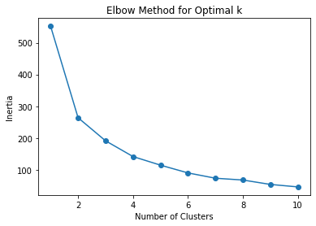

|  | Item | Calories | Fat (g) | Carb. (g) | Fiber (g) | Protein | Sodium | Cluster |
| --- | --- | --- | --- | --- | --- | --- | --- | --- |
| 0 | Cool Lime Starbucks Refreshers™ Beverage | 45.0 | 0.0 | 11.0 | 0.0 | 0.0 | 10.0 | 2 |
| 1 | Strawberry Acai Starbucks Refreshers™ Beverage | 80.0 | 0.0 | 18.0 | 1.0 | 0.0 | 10.0 | 2 |
| 2 | Very Berry Hibiscus Starbucks Refreshers™ Beve... | 60.0 | 0.0 | 14.0 | 1.0 | 0.0 | 10.0 | 2 |
| 3 | Evolution Fresh™ Organic Ginger Limeade | 110.0 | 0.0 | 28.0 | 0.0 | 0.0 | 5.0 | 0 |
| 4 | Iced Coffee | 0.0 | 0.0 | 0.0 | 0.0 | 0.0 | 0.0 | 2 |
| ... | ... | ... | ... | ... | ... | ... | ... | ... |
| 87 | Mocha Light Frappuccino® Blended Coffee | 140.0 | 0.5 | 28.0 | 1.0 | 4.0 | 180.0 | 5 |
| 88 | Cinnamon Dolce Crème | 200.0 | 6.0 | 28.0 | 0.0 | 10.0 | 135.0 | 1 |
| 89 | Vanilla Crème | 200.0 | 6.0 | 28.0 | 0.0 | 10.0 | 135.0 | 1 |
| 90 | Chocolate Smoothie | 320.0 | 5.0 | 53.0 | 8.0 | 20.0 | 170.0 | 4 |
| 91 | Strawberry Smoothie | 300.0 | 2.0 | 60.0 | 7.0 | 16.0 | 130.0 | 4 |

92 rows × 8 columns

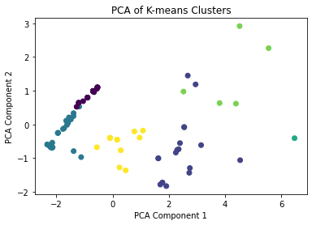

```python
print('Starbucks:')
sb_features = starbucks_new_df[['Calories', 'Fat (g)', 'Carb. (g)', 'Fiber (g)', 'Protein', 'Sodium']]

scaler = StandardScaler()
sb_features_scaled = scaler.fit_transform(sb_features)

inertia = []
k_range = range(1, 11)

for k in k_range:
    kmeans = KMeans(n_clusters=k, random_state=42)
    kmeans.fit(sb_features_scaled)
    inertia.append(kmeans.inertia_)

plt.plot(k_range, inertia, marker='o')
plt.xlabel("Number of Clusters")
plt.ylabel("Inertia")
plt.title("Elbow Method for Optimal k")
plt.show()

k = 6
kmeans = KMeans(n_clusters=k, random_state=42)
kmeans.fit(sb_features_scaled)


starbucks_new_df['Cluster'] = kmeans.labels_
display(starbucks_new_df)

pca = PCA(n_components=2)
sb_features_pca = pca.fit_transform(sb_features_scaled)

plt.scatter(sb_features_pca[:, 0], sb_features_pca[:, 1], c=kmeans.labels_, cmap='viridis')
plt.xlabel("PCA Component 1")
plt.ylabel("PCA Component 2")
plt.title("PCA of K-means Clusters")
plt.show()
```

```
McDonalds:
```

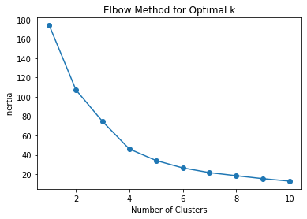

|  | Item | Calories | Fat (g) | Carb. (g) | Fiber (g) | Protein | Sodium | Cluster |
| --- | --- | --- | --- | --- | --- | --- | --- | --- |
| 0 | Iced Tea | 0.0 | 0.0 | 0.0 | 0.0 | 0.0 | 5.0 | 1 |
| 1 | Sweet Tea | 110.0 | 0.0 | 27.0 | 0.0 | 0.0 | 5.0 | 1 |
| 2 | Coffee | 0.0 | 0.0 | 0.0 | 0.0 | 0.0 | 0.0 | 1 |
| 3 | Latte | 170.0 | 9.0 | 15.0 | 1.0 | 9.0 | 115.0 | 0 |
| 4 | Caramel Latte | 270.0 | 9.0 | 40.0 | 1.0 | 9.0 | 115.0 | 0 |
| 5 | Hazelnut Latte | 270.0 | 9.0 | 40.0 | 1.0 | 9.0 | 115.0 | 0 |
| 6 | French Vanilla Latte | 260.0 | 9.0 | 38.0 | 1.0 | 9.0 | 115.0 | 0 |
| 7 | Latte with Sugar Free French Vanilla Syrup | 210.0 | 9.0 | 24.0 | 1.0 | 9.0 | 150.0 | 0 |
| 8 | Nonfat Latte | 100.0 | 0.0 | 15.0 | 1.0 | 10.0 | 110.0 | 0 |
| 9 | Nonfat Caramel Latte | 200.0 | 0.0 | 41.0 | 1.0 | 10.0 | 110.0 | 0 |
| 10 | Nonfat Hazelnut Latte | 200.0 | 0.0 | 40.0 | 1.0 | 10.0 | 110.0 | 0 |
| 11 | Nonfat French Vanilla Latte | 190.0 | 0.0 | 39.0 | 1.0 | 10.0 | 115.0 | 0 |
| 12 | Nonfat Latte with Sugar Free French Vanilla Sy... | 140.0 | 0.0 | 24.0 | 1.0 | 10.0 | 150.0 | 0 |
| 13 | Mocha | 340.0 | 11.0 | 49.0 | 2.0 | 10.0 | 150.0 | 0 |
| 14 | Mocha with Nonfat Milk | 270.0 | 3.5 | 49.0 | 2.0 | 11.0 | 150.0 | 0 |
| 15 | Caramel Mocha | 320.0 | 11.0 | 45.0 | 1.0 | 10.0 | 170.0 | 0 |
| 16 | Nonfat Caramel Mocha | 250.0 | 3.5 | 45.0 | 1.0 | 10.0 | 170.0 | 0 |
| 17 | Hot Chocolate | 360.0 | 13.0 | 50.0 | 1.0 | 11.0 | 180.0 | 0 |
| 18 | Hot Chocolate with Nonfat Milk | 280.0 | 3.5 | 50.0 | 1.0 | 12.0 | 180.0 | 0 |
| 19 | Iced Mocha | 290.0 | 11.0 | 41.0 | 1.0 | 8.0 | 125.0 | 0 |
| 20 | Iced Mocha with Nonfat Milk | 240.0 | 5.0 | 41.0 | 1.0 | 8.0 | 125.0 | 0 |
| 21 | Iced Caramel Mocha | 280.0 | 11.0 | 38.0 | 0.0 | 8.0 | 140.0 | 0 |
| 22 | Iced Nonfat Caramel Mocha | 230.0 | 5.0 | 38.0 | 0.0 | 8.0 | 140.0 | 0 |
| 23 | Frappé Mocha | 450.0 | 18.0 | 65.0 | 1.0 | 7.0 | 125.0 | 3 |
| 24 | Frappé Caramel | 450.0 | 19.0 | 64.0 | 0.0 | 7.0 | 125.0 | 3 |
| 25 | Frappé Chocolate Chip | 530.0 | 23.0 | 76.0 | 1.0 | 8.0 | 135.0 | 3 |
| 26 | Blueberry Pomegranate Smoothie | 220.0 | 0.5 | 50.0 | 3.0 | 2.0 | 40.0 | 2 |
| 27 | Strawberry Banana Smoothie | 210.0 | 0.5 | 47.0 | 3.0 | 3.0 | 50.0 | 2 |
| 28 | Mango Pineapple Smoothie | 210.0 | 0.5 | 50.0 | 1.0 | 2.0 | 40.0 | 2 |

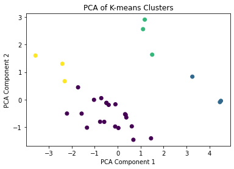

```python
print('McDonalds:')
mc_features = mcdonalds_new_df[['Calories', 'Fat (g)', 'Carb. (g)', 'Fiber (g)', 'Protein', 'Sodium']]

scaler = StandardScaler()
mc_features_scaled = scaler.fit_transform(mc_features)

inertia = []
k_range = range(1, 11)

for k in k_range:
    kmeans = KMeans(n_clusters=k, random_state=42)
    kmeans.fit(mc_features_scaled)
    inertia.append(kmeans.inertia_)

plt.plot(k_range, inertia, marker='o')
plt.xlabel("Number of Clusters")
plt.ylabel("Inertia")
plt.title("Elbow Method for Optimal k")
plt.show()

k = 4
kmeans = KMeans(n_clusters=k, random_state=42)
kmeans.fit(mc_features_scaled)


mcdonalds_new_df['Cluster'] = kmeans.labels_
display(mcdonalds_new_df)

pca = PCA(n_components=2)
mc_features_pca = pca.fit_transform(mc_features_scaled)

plt.scatter(mc_features_pca[:, 0], mc_features_pca[:, 1], c=kmeans.labels_, cmap='viridis')
plt.xlabel("PCA Component 1")
plt.ylabel("PCA Component 2")
plt.title("PCA of K-means Clusters")
plt.show()
```

These clusterings allow me to answer my last quesiton of how similar the items are in each dataset. By looking at each cluster value, I can now see which items are similar to eachother due to the kmeans algorithm. For example, in the McDonalds dataset, the "Blueberry Pomegranate Smoothie," "Strawberry Banana Smoothie," and "Mango Pineapple Smoothie" are all in the 2nd cluster, so that means that they are similar to eachother nutritionally, which by looking at their values makes sense.

# Conclusion

Overall, I would say this was a successful attempt at data exploration. I was able to answer most of my questions. I could answer which company had the higher average values for each of their nutritional values (McDonalds), I found a pretty simple way to visualize the datasets (a bargraph), and I found a way to see how similar each item in each dataset is nutritionally (using the kmeans algorithm and principal componenet analysis). I could not answer which items are better/worse from eachother if both companies make the same product due to not wanting to assume items that looked similar contianed the same things.

The only thing I found that I was not origionally looking for were the medians of each column's value due to being shocked that the averages of McDonalds were higher in every aspect.

A problem that I ran into was when I was trying to merge the dataframes and nothing matched due to the menus having different names for what seemed like similar items.

Future research would inclue looking into what is in the drinks that sounded similar to see if it makes sense to be able to compare them or not even though they have different menu names. It would also include finding values for the NaN values in the Starbucks menu.